# Hotel Group analysis

David

28/11/2021

## Introduction:

In this notebook are reports and observations from a worldwide group of hotels.

In detail I will report:

1. The types of hotels the group has
2. The busiest months of the year for each type of hotel
3. The Ranking of Hotel Packages sold
4. Which market segment makes the most reservations per hotel type

## Let’s start

### 1. The types of hotels the group has:

| Types of Hotels |
| --- |
| Resort Hotel |
| City Hotel |

### 2. The busiest months of the year for each type of hotel

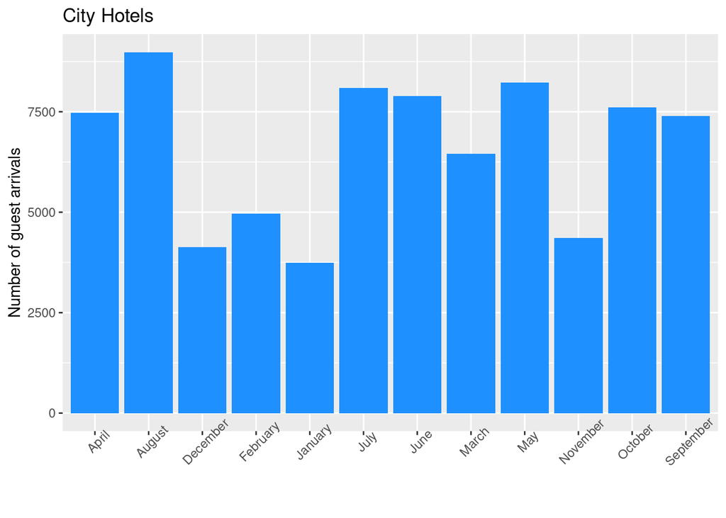

| Months | Arrivals |
| --- | --- |
| August | 8983 |
| May | 8232 |
| July | 8088 |
| June | 7894 |
| October | 7605 |
| April | 7480 |
| September | 7400 |
| March | 6458 |
| February | 4965 |
| November | 4357 |
| December | 4132 |
| January | 3736 |

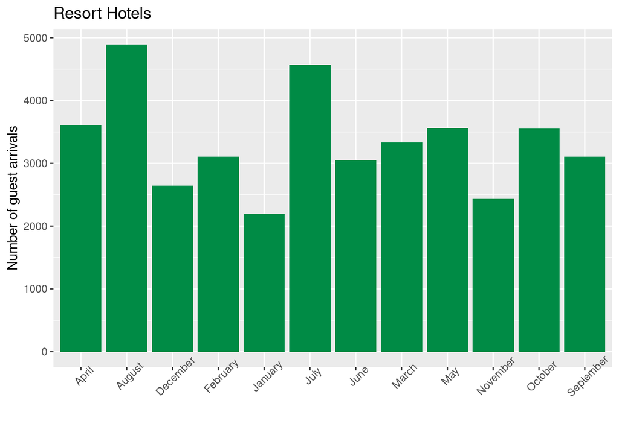

| Months | Arrivals |
| --- | --- |
| August | 4894 |
| July | 4573 |
| April | 3609 |
| May | 3559 |
| October | 3555 |
| March | 3336 |
| September | 3108 |
| February | 3103 |
| June | 3045 |
| December | 2648 |
| November | 2437 |
| January | 2193 |